# Project 2: Patterns in FDA Food and Drug Recall Announcements

**Sally Choi**

## Project Overview

The U.S. Food and Drug Administration (FDA) maintains the Recalls, Market Withdrawals, and Safety Alerts website to inform the public about products that may pose health or safety risks. Its listings describe affected products, company and brand names, recall reasons, and whether a recall is marked as terminated. The announcements cover different concerns, including undeclared ingredients, possible contamination, and manufacturing problems.

For Project 1, I collected seven fields from the FDA results table on October 20, 2026, restricting the searches to Food & Beverages and Drugs. For this project, I imported that dataset into a separate notebook to examine the distribution of listings over time, compare recall reasons across the two groups, and describe the products and companies represented. I also looked more closely at specific allergens mentioned in food listings and addressed the Project 1 feedback about whether missing termination information varies by recall year. Each observation represents one listing, which may describe more than one product or brand.

### Key findings

Food & Beverages accounts for most of the dataset, with 777 of the 953 listings, compared with 178 for Drugs; two listings belong to both groups. The selected recall-reason themes differ across the groups: 40.4% of food listings mention undeclared ingredients or allergens, while 15.7% of drug listings mention that theme and 14.6% mention methanol. Within the 314 food listings matching the undeclared-ingredient or allergen theme, milk is the most frequently mentioned of the six ingredients examined, appearing in 92 descriptions. Company appearances are spread across 808 recorded names, with only six listings each for the two most frequently recorded names. Finally, missing termination information is more common in recent years, ranging from 75.0% to 85.2% in 2024–2026, compared with 9.9% in 2023. This pattern is consistent with a relationship between year and missing information, although a blank field does not confirm that a recall is ongoing.

```python
# Load packages
import pandas as pd
import matplotlib.pyplot as plt

# Packages for graph/output
from matplotlib.ticker import MaxNLocator, PercentFormatter
from IPython.display import display
```

```python
# Load dataset
recalls = pd.read_csv("fda_food_drug_recalls.csv")

# Blank cells as missing values
recalls = recalls.replace(r"^\s*$", pd.NA, regex=True)

# Dates and listing year
recalls["Date"] = pd.to_datetime(recalls["Date"])
recalls["Year"] = recalls["Date"].dt.year

# Missing termination indicator
recalls["Termination missing"] = recalls["Terminated Recall"].isna()
```

```python
groups = ["Food & Beverages", "Drugs"]

# Overlapping food and drug labels
membership = pd.DataFrame()
for group in groups:
    membership[group] = recalls["Product Type"].str.contains(group, regex=False)
```

```python
# Food: teal, Drugs: orange
colors = ["#207F8C", "#D87943"]

# Shared graph formatting
plt.rcParams.update({
    "font.size": 11,
    "axes.titlesize": 14,
    "axes.titleweight": "bold",
    "axes.spines.top": False,
    "axes.spines.right": False,
    "figure.figsize": (10, 5),
    "figure.dpi": 130})
```

```python
def show_table(frame, caption, formats=None):
    # Index and number formatting
    table = frame.style.hide(axis="index").format(formats or {})

    # Caption/spacing
    table = table.set_caption(caption)
    table = table.set_properties(**{"padding": "8px"})

    # Header and alternating row colors
    table = table.set_table_styles([
        {"selector": "th", "props": [
                ("background-color", "#183747"),
                ("color", "white"),
                ("padding", "8px")]},
        {"selector": "caption", "props": [
                ("text-align", "left"),
                ("font-weight", "bold"),
                ("padding", "10px 0")]},
        {"selector": "tbody tr:nth-child(even)",
        "props": [("background-color", "#F1F6F7")]}
        ])

    display(table)
```

## Data source and collection

I collected the data from the [FDA Recalls, Market Withdrawals, and Safety Alerts table](https://www.fda.gov/safety/recalls-market-withdrawals-safety-alerts) on October 20, 2026. The Project 1 algorithm used Selenium to select Food & Beverages and Drugs, display 100 entries per page, and click Next until the results were collected. It recorded Date, Brand Name(s), Product Description, Product Type, Recall Reason Description, Company Name, and Terminated Recall. Two listings appeared in both searches, so I removed the repeated copies while preserving their original category labels.

I did not apply a date filter, visit the separate archive, or collect information from individual announcement pages. The dates in the saved data range from October 19, 2017, to October 17, 2026, but that range does not establish complete coverage of every year. The report describes the main-table listings available when I collected them rather than all FDA recalls during that period.

## Data preparation and overview

I treated empty or whitespace-only cells as missing and converted Date to a date format so that I could extract the listing year. I also created an indicator for missing termination information and kept separate food and drug membership indicators. These indicators preserve the two listings that belong to both groups, so group counts add to 955 even though the combined dataset has 953 observations. Percentages within each product group use that group's own listing count, while percentages described as shares of the full dataset use 953 as the denominator.

The first two tables summarize completeness and group membership. I also checked for duplicate rows across the seven collected fields and for listings outside both selected product groups.

```python
# Original fields only
source_columns = [c for c in recalls.columns if c not in ["Year", "Termination missing"]]

# Missing counts and percentages
quality = pd.DataFrame({
    "Field": source_columns,
    "Observations": len(recalls),
    "Missing": recalls[source_columns].isna().sum().values,
    "Missing (%)": recalls[source_columns].isna().mean().values * 100})
show_table(quality, "Table 1. Dataset coverage and missing values", {"Missing (%)": "{:.1f}%"})

# Group counts with overlapping membership
composition = pd.DataFrame({"Product group": groups, "Listings": membership.sum().values})
composition["Share of all listings (%)"] = composition["Listings"] / len(recalls) * 100
show_table(composition, "Table 2. Product-group membership (two listings overlap)",
           {"Share of all listings (%)": "{:.1f}%"})

# Duplicate and category checks
print(f"Duplicate rows: {recalls[source_columns].duplicated().sum()} | "
      f"Listings outside both selected groups: {(~membership.any(axis=1)).sum()}")
```

Table 1. Dataset coverage and missing values

| Field | Observations | Missing | Missing (%) |
| --- | --- | --- | --- |
| Date | 953 | 0 | 0.0% |
| Brand Name(s) | 953 | 0 | 0.0% |
| Product Description | 953 | 0 | 0.0% |
| Product Type | 953 | 0 | 0.0% |
| Recall Reason Description | 953 | 0 | 0.0% |
| Company Name | 953 | 0 | 0.0% |
| Terminated Recall | 953 | 659 | 69.2% |

Table 2. Product-group membership (two listings overlap)

| Product group | Listings | Share of all listings (%) |
| --- | --- | --- |
| Food & Beverages | 777 | 81.5% |
| Drugs | 178 | 18.7% |

```
Duplicate rows: 0 | Listings outside both selected groups: 0
```

The dataset contains 953 listings, including 777 with a Food & Beverages label (81.5%) and 178 with a Drugs label (18.7%). These shares slightly exceed 100% when added because two listings include both labels. No missing values appear in the first six collected fields, and no duplicate rows remain. Terminated Recall is the only incomplete field, with 659 blank entries, or 69.2% of the dataset. I kept these blanks as missing information rather than assigning a recall status that was not recorded.

The collected fields do not include a direct numeric measurement such as price, quantity, or the number of affected units. Counts and percentages are therefore the most useful summary statistics for the variables available, while year is used to compare the distribution of listings over time.

## Recall listings over time

I counted listings by year within each product group to show where the observations fall in the collected period. Food and drug counts are displayed side by side so that differences in their time coverage are visible. These counts describe the saved dataset rather than changes in the underlying frequency or risk of recalls, because the separate archive was not collected and the 2026 records end on October 17.

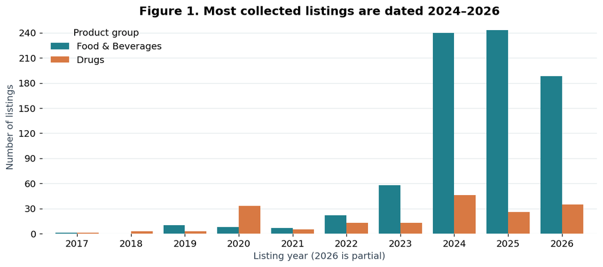

```python
# Annual counts within each product group
annual = pd.DataFrame({g: recalls.loc[membership[g]].groupby("Year").size() for g in groups}).fillna(0)

# Side-by-side annual bars
fig, ax = plt.subplots(figsize=(10, 4.5))
annual.plot.bar(ax=ax, color=colors, width=0.8, rot=0)
ax.yaxis.set_major_locator(MaxNLocator(integer=True))
ax.legend(title="Product group", frameon=False)

# Titles, labels, and grid
ax.set(title='Figure 1. Most collected listings are dated 2024–2026', xlabel='Listing year (2026 is partial)', ylabel='Number of listings')
ax.set_axisbelow(True)
ax.grid(axis='y', color="#E3E9EC")
plt.tight_layout()
plt.show()
```

The dataset is concentrated in 2024–2026, which together contribute 777 listings, or 81.5% of all observations. Annual totals rise from 71 in 2023 to 286 in 2024, followed by 268 in 2025 and 223 in the partial 2026 period. Food listings contribute most of the records in these recent years, while Drugs makes up a larger share of some smaller, older-year totals.

These differences help explain which periods drive the remaining results, but they should not be described as evidence of a rise in recalls. The FDA states that recall announcements remain on its current website for three years before being archived. That supports the interpretation that the dataset’s concentration in recent years reflects its coverage, rather than necessarily an increase in recalls. I collected announcements from the FDA’s main results table but did not include the separate archive, which may contain additional older records.

## Reasons for recalls

Recall Reason Description is a free-text field, so the same concern can be written in different ways. I selected six themes to compare several types of concerns recorded in the recall descriptions: Listeria, Salmonella, undeclared ingredients or allergens, sterility, lead, and methanol. These themes cover pathogen-related concerns, ingredient disclosure, sterility, and chemical contamination, allowing a focused comparison between food and drug listings. They are not an exhaustive classification or necessarily the six most common recall reasons. For example, the sterility search matches words containing “steril,” while the lead search requires a whole-word match.

For each theme, I calculated the percentage of listings in each product group whose description matched the search. A description can match more than one theme, so the percentages are not intended to add to 100%. Listings without any selected terms remain in the denominator. The themes provide a focused comparison instead of a complete classification.

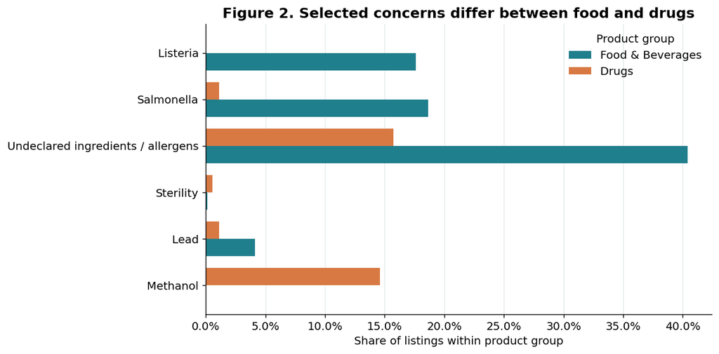

Table 3. Number of listings matching each selected reason theme

| Text theme | Matching listings |
| --- | --- |
| Listeria | 137 |
| Salmonella | 145 |
| Undeclared ingredients / allergens | 342 |
| Sterility | 2 |
| Lead | 34 |
| Methanol | 26 |

```python
# Selected recall-reason searches
patterns = {
    "Listeria": r"listeria", "Salmonella": r"salmonella",
    "Undeclared ingredients / allergens": r"undeclared|allergen",
    "Sterility": r"steril", "Lead": r"\blead\b", "Methanol": r"methanol"}

# Theme indicators for each listing
reason_flags = pd.DataFrame({label: recalls["Recall Reason Description"].str.contains(
    pattern, case=False, regex=True, na=False) for label, pattern in patterns.items()})

# Percentages within each product group
reason_pct = pd.DataFrame({g: reason_flags.loc[membership[g]].mean() * 100 for g in groups})

# Group comparison and matching counts
fig, ax = plt.subplots(figsize=(10, 5))
reason_pct.iloc[::-1].plot.barh(ax=ax, color=colors, width=0.75)
ax.legend(title="Product group", frameon=False)

# Titles, labels, and grid
ax.set(title='Figure 2. Selected concerns differ between food and drugs', xlabel='Share of listings within product group', ylabel='')
ax.set_axisbelow(True)
ax.grid(axis='x', color="#E3E9EC")
ax.xaxis.set_major_formatter(PercentFormatter(100))
plt.tight_layout()
plt.show()
show_table(reason_flags.sum().rename_axis("Text theme").reset_index(name="Matching listings"),
           "Table 3. Number of listings matching each selected reason theme")
```

### Recall-reason findings

Undeclared ingredients or allergens appear in 40.4% of food listings, making this the largest of the six selected themes within that group. Salmonella appears in 18.7%, followed by Listeria at approximately 17.6%, which shows that both ingredient disclosure and pathogen-related concerns are prominent in the collected food descriptions. The combined “undeclared ingredients or allergens” theme is broader than confirmed allergen recalls because the search also includes other undeclared ingredients.

For Drugs, 15.7% of listings mention undeclared ingredients or allergens and 14.6% mention methanol. Methanol appears much more frequently within drug listings than food listings, while the pathogen themes are more prominent among food listings. These differences describe the wording of the recorded reasons and help identify concerns worth examining more closely; they do not compare the severity of recalls or represent every possible reason in either group.

## Products and additional FDA labels

The Product Description field contains detailed free text rather than a consistent product classification. Instead of assigning subjective product categories, I used the additional labels already recorded in Product Type. The table includes product labels and safety labels, so it should not be read as a ranking of mutually exclusive product categories. Repeated labels within one listing are counted once, while a listing can contribute to several labels.

I split the recorded category text at commas, removed repeated labels within the same listing, and excluded the two main search labels before ranking the remaining terms. Because this method follows the source's comma-separated text, a compound label such as “Spices, Flavors & Salts” is displayed as separate terms. I refer to the results as additional labels rather than treating every extracted term as a distinct product category.

```python
# Individual labels; one count per listing
labels = recalls["Product Type"].str.split(", ").explode().rename("FDA label").reset_index()
labels = labels.drop_duplicates(["index", "FDA label"])

# Ten most frequent labels beyond food and drugs
extra_labels = labels.loc[~labels["FDA label"].isin(groups), "FDA label"].value_counts().head(10)

# Shares of the full dataset
label_table = extra_labels.rename_axis("Additional FDA label").reset_index(name="Listings")
label_table["Share of all listings (%)"] = label_table["Listings"] / len(recalls) * 100
show_table(label_table, "Table 4. Ten most common additional FDA labels",
           {"Share of all listings (%)": "{:.1f}%"})
```

Table 4. Ten most common additional FDA labels

| Additional FDA label | Listings | Share of all listings (%) |
| --- | --- | --- |
| Foodborne Illness | 267 | 28.0% |
| Allergens | 218 | 22.9% |
| Contaminants | 34 | 3.6% |
| Animal & Veterinary | 33 | 3.5% |
| Dietary Supplements | 21 | 2.2% |
| Produce | 19 | 2.0% |
| Cheese/Cheese Product | 15 | 1.6% |
| Pet Food | 13 | 1.4% |
| Shellfish | 12 | 1.3% |
| Snack Food Item | 9 | 0.9% |

Foodborne Illness and Allergens are the most common additional labels, appearing in 267 and 218 distinct listings, respectively. Other labels identify narrower product areas or concerns, including Contaminants, Animal & Veterinary, Pet Food, Dietary Supplements, and Produce. This shows that the original searches include more variety than a simple food-versus-drugs comparison suggests, particularly where listings carry several category labels.

The table also illustrates a limitation of the recorded categories: product types and safety concerns appear in the same field, and some listings have much more specific labels than others. A listing can contribute to several rows, so the percentages do not add to 100%. These labels provide useful context but cannot establish a complete, mutually exclusive breakdown of the products affected.

## Specific allergens mentioned in food listings

To examine the largest selected food-reason theme in more detail, I restricted this analysis to food listings whose descriptions mention “undeclared” or “allergen.” I then searched those descriptions for six specific ingredients: milk, wheat, soy, egg, peanut, and sesame. The searches use whole words and include common plural forms, with soybean also included under soy.

The denominator is the 314 food listings matching the broader undeclared-ingredient or allergen search, rather than all food listings. These six ingredients are a selected set, so the chart does not include every possible allergen. A description can mention several ingredients, and a match does not establish whether that ingredient was undeclared rather than appearing elsewhere in the explanation.

```python
# Food descriptions mentioning undeclared ingredients or allergens
food_allergen = membership["Food & Beverages"] & reason_flags["Undeclared ingredients / allergens"]
allergen_reasons = recalls.loc[food_allergen, "Recall Reason Description"]

# Whole-word ingredient searches
allergen_patterns = {
    "Milk": r"\bmilk\b", "Wheat": r"\bwheat\b", "Soy": r"\bsoy(?:bean)?s?\b",
    "Egg": r"\beggs?\b", "Peanut": r"\bpeanuts?\b", "Sesame": r"\bsesame\b"}
allergen_counts = {}
for ingredient, pattern in allergen_patterns.items():
    allergen_counts[ingredient] = allergen_reasons.str.contains(pattern, case=False).sum()
```

Table 6. Selected ingredient mentions in 314 food listings

| Ingredient | Listings | Share of selected listings (%) |
| --- | --- | --- |
| Milk | 92 | 29.3% |
| Wheat | 59 | 18.8% |
| Soy | 53 | 16.9% |
| Egg | 42 | 13.4% |
| Sesame | 36 | 11.5% |
| Peanut | 31 | 9.9% |

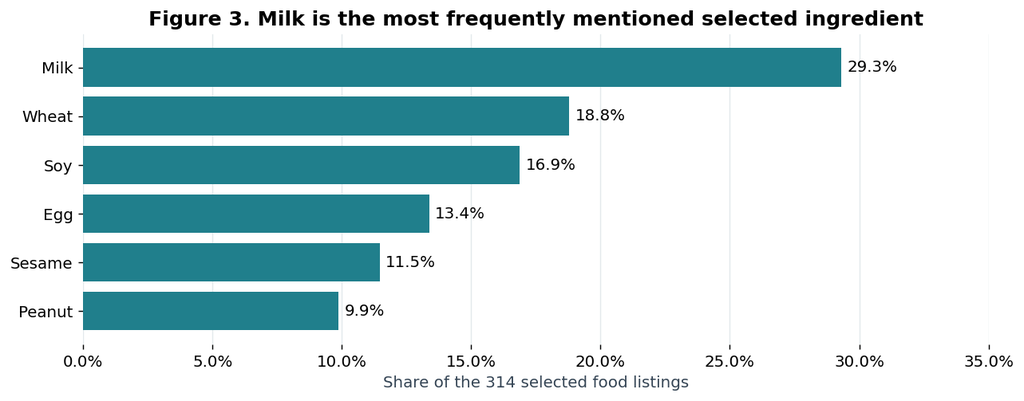

```python
# Counts and percentages within the selected food subset
allergen_summary = pd.DataFrame({"Ingredient": allergen_counts.keys(), "Listings": allergen_counts.values()})
allergen_summary["Share of selected listings (%)"] = allergen_summary["Listings"] / len(allergen_reasons) * 100
allergen_summary = allergen_summary.sort_values("Listings", ascending=False)
show_table(allergen_summary, "Table 6. Selected ingredient mentions in 314 food listings",
           {"Share of selected listings (%)": "{:.1f}%"})

# Ranked percentages with direct labels
plot_data = allergen_summary.sort_values("Listings")
fig, ax = plt.subplots(figsize=(10, 4))
ax.barh(plot_data["Ingredient"], plot_data["Share of selected listings (%)"], color=colors[0])
ax.bar_label(ax.containers[0], fmt="%.1f%%", padding=4)
ax.set(title="Figure 3. Milk is the most frequently mentioned selected ingredient",
       xlabel="Share of the 314 selected food listings", xlim=(0, 35))
ax.xaxis.set_major_formatter(PercentFormatter(100))
ax.grid(axis="x", color="#E3E9EC")
ax.set_axisbelow(True)
plt.tight_layout()
plt.show()
```

Milk appears in 92 of the 314 selected food listings (29.3%), followed by wheat in 59 (18.8%) and soy in 53 (16.9%). Egg appears in 42 descriptions (13.4%), sesame in 36 (11.5%), and peanut in 31 (9.9%). Milk is therefore the most frequently mentioned of the six ingredients examined, but this does not establish that it is the leading allergen across all FDA recalls.

The percentages describe ingredient mentions within this selected subset, and they can overlap when a description names several ingredients. Some descriptions may use broader terms or different wording, while others may mention allergens outside the six searches, so this analysis is useful for describing the available text rather than estimating the prevalence or severity of specific allergen problems.

## Companies and repeated listings

I counted appearances by Company Name after trimming spaces at the beginning and end of each value. I retained the source's spelling and did not combine subsidiaries, related businesses, or similar names, so the results describe recorded company names rather than independently verified corporate entities. The figure shows five names from each product group with the highest listing counts, using the same horizontal scale for both panels.

A company can appear in several listings because of separate announcements, affected products, or updates, which the listing-level dataset cannot fully distinguish. These counts therefore describe repeated appearances in the collected table rather than independent safety incidents.

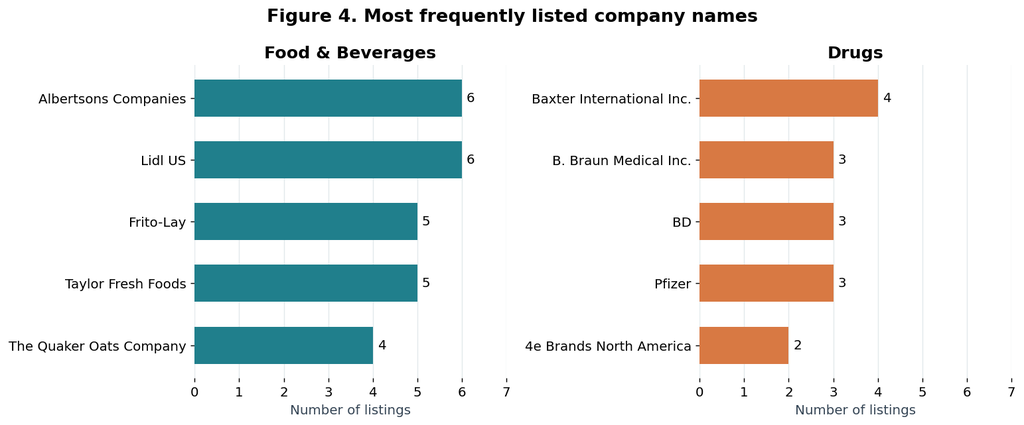

```python
# Listing counts by recorded company name
company = recalls["Company Name"].str.strip()
company_counts = company.value_counts()

# Five names per group
fig, axes = plt.subplots(1, 2, figsize=(12, 5))
for ax, group, color in zip(axes, groups, colors):
    top = company.loc[membership[group]].value_counts().head(5).sort_values()
    ax.barh(top.index, top.values, color=color, height=0.6)
    ax.bar_label(ax.containers[0], padding=4)
    ax.set(title=group, xlabel="Number of listings", xlim=(0, company_counts.max() + 1))
    ax.xaxis.set_major_locator(MaxNLocator(integer=True))
    ax.grid(axis="x", color="#E3E9EC")
    ax.set_axisbelow(True)
fig.suptitle("Figure 4. Most frequently listed company names", fontsize=15, fontweight="bold")
plt.tight_layout()
plt.show()
```

Without company sales, the number of products sold, or a consistent way to identify related businesses, these comparisons cannot establish which companies have higher recall rates or are less safe. Their value is in describing how widely the announcements are distributed across the recorded names.

## Missing termination information

A suggestion from project 1 was made to examine whether blank Terminated Recall fields are partly explained by recall year, since more recent recalls may still be ongoing. I calculated the number and percentage of missing values within each year, then compared the percentages separately for Food & Beverages and Drugs. The annual table includes both overall and group-specific observation counts so that large percentage differences can be considered alongside the number of listings supporting them.

A blank field means that termination information was not recorded in the collected table; it does not confirm that a recall is ongoing. This analysis therefore examines whether missingness is associated with year, while leaving the reason for individual blank entries unresolved. A gap in a group's line indicates a year with no listings for that group, rather than a missing rate of zero.

Table 5. Missing termination information by listing year

| Year | Listings | Missing | Missing (%) | Food & Beverages (n) | Drugs (n) |
| --- | --- | --- | --- | --- | --- |
| 2017 | 2 | 1 | 50.0% | 1 | 1 |
| 2018 | 3 | 2 | 66.7% | 0 | 3 |
| 2019 | 13 | 5 | 38.5% | 10 | 3 |
| 2020 | 41 | 16 | 39.0% | 8 | 33 |
| 2021 | 12 | 5 | 41.7% | 7 | 5 |
| 2022 | 34 | 4 | 11.8% | 22 | 13 |
| 2023 | 71 | 7 | 9.9% | 58 | 13 |
| 2024 | 286 | 228 | 79.7% | 240 | 46 |
| 2025 | 268 | 201 | 75.0% | 243 | 26 |
| 2026 | 223 | 190 | 85.2% | 188 | 35 |

[figure not shown]

```python
# Annual totals and missing termination counts
missing_year = recalls.groupby("Year").agg(
    Listings=("Date", "size"), Missing=("Termination missing", "sum"))
missing_year["Missing (%)"] = missing_year["Missing"] / missing_year["Listings"] * 100

# Group sample sizes for interpreting percentages
for group in groups:
    missing_year[group + " (n)"] = recalls.loc[membership[group]].groupby("Year").size().reindex(missing_year.index, fill_value=0)
show_table(missing_year.reset_index(), "Table 5. Missing termination information by listing year",
           {"Year": "{:.0f}", "Missing (%)": "{:.1f}%"})

# Missing percentages within each group and year
fig, ax = plt.subplots(figsize=(10, 4.5))
for group, color in zip(groups, colors):
    rates = recalls.loc[membership[group]].groupby("Year")["Termination missing"].mean() * 100
    ax.plot(missing_year.index, rates.reindex(missing_year.index).values, marker="o", color=color, linewidth=2, label=group)
ax.set_xticks(missing_year.index)
ax.set_ylim(0, 105)
ax.yaxis.set_major_formatter(PercentFormatter(100))
ax.legend(title="Product group", frameon=False)

# Graph settings
ax.set(title='Figure 5. Recent listings more often lack termination information',
       xlabel='Listing year (2026 is partial)',
       ylabel='Listings with missing termination information (%)')
ax.set_axisbelow(True)
ax.grid(axis='y', color="#E3E9EC")
plt.tight_layout()
plt.show()
```

Missing termination information is much more common in recent years: 79.7% of listings in 2024, 75.0% in 2025, and 85.2% in 2026 have blank fields, compared with 9.9% in 2023 and 11.8% in 2022. This is consistent with the expectation that recent recalls may be less likely to have reached a recorded termination, although the relationship is not a steady increase across every year. Missingness also differs across product groups; all drug listings dated 2025 and 2026 lack termination information in this dataset.

Older-year percentages needs more care when examining because the dataset has only two listings in 2017 and three in 2018. So, a single blank field can substantially change the percentage when the denominator is that small. The larger recent-year totals make the high missing percentages more broadly representative of the collected recent listings, but they still do not explain why a field is blank.

Recall year helps characterize which records lack termination information, but the data do not include termination dates, follow-up histories, or a confirmed status for blank entries. I therefore cannot separate the effects of time since listing, product-group differences, and reporting practices. The main response to the feedback is that missingness is patterned by year and product group, so interpreting every blank as an ongoing recall would hide meaningful differences in the available information.

## Discussion and limitations

The collected announcements reveal several related patterns: food listings make up most of the dataset, selected recall-reason themes differ between food and drugs, and repeated company appearances are distributed across many recorded names. The additional FDA labels broaden the picture by identifying overlapping safety concerns and product areas, while the ingredient analysis shows which specific allergens are mentioned within the selected food descriptions. Together, these summaries explain both the composition of the data and the concerns recorded in the announcements.

The missingness analysis adds an important qualification to the results. Termination information is less complete among recent listings, and the pattern also differs between food and drugs, so blanks should remain a separate information category rather than being assigned a confirmed status. This addresses the Project 1 feedback while preserving the limits of what the collected table can establish.

The findings describe listings available in the two selected main-table searches at one point in time. They do not measure recall rates, affected units, severity, or consumer exposure, and the absence of archived records limits historical comparisons. The partial 2026 period, overlapping product labels, variations in company names, and text-based reason searches also affect interpretation. Within these limits, the analysis provides a clearer description of the announcements without treating listing counts or missing fields as evidence of risk or recall status.